# Genralization analysis in deforestation and forest samples in Amazon Forest

# Introduction

The Amazon forest is the largest rainforest in the world, and it has a vital role in the carbon cycle and climate regulation. The majority of the Amazon forest is in Brazil, about 60%. Since the end of 80 decade, the Brazilian government has maintained projects based on remote sensing images to monitor the region. PRODES, launched in 1988, is a project with global respect, and it was responsible for a considerable decrease in the deforestation rate in the 90s and the beginning of the 2000s. However, deforestation has increased over the past 15 years, which concerns the Brazilian government.

Even with the evolution of machine learning methods, the visual analysis of the images is the primary method in PRODES and other monitoring projects. For some reason, the region is covered by clouds almost all year, which can result in noise samples and a low number of images with soil information. Another reason is the variability of the samples observed in the region. The Amazon forest has a distinct response over a year and more; the forest may be different depending on the location, and this can result in multiple patterns. Also, deforestation only occurs occasionally, presenting distinct patterns to samples. So, a machine learning method to produce information can be complex.

Considering the sampling process in machine learning methods, understanding how samples behave spatial and temporal is fundamental to improving the results of machine learning methods. Therefore, this work aims to produce a statistical analysis of samples of deforestation and forest in the Amazon forest to understand how much the patterns are different in the deforest and forest classes. Also, we analyze different samples in space and time to verify how much is possible generalize a clustering method.

# Hypotheses

General

- Can use short time series to improve the generalization of model?
- Is there a relationship between samples in different region and time?
- Is it possible generate a generic clustering algorithm considering time and space variation?

Spatial

- Samples in different tile can be classify using an single tile as reference.
- The patterns are similar in different tiles.
- Is possible produce a ML model generic as possible to classify different region?

Temporal

- Samples in a specific time step can be used to classify samples in the future
- The seasonal behavior of time series happen in the next years

# Functions used

```r
source("../src/data.R")
```

```r
source("../src/stats.R")
```

```r
source("../src/plot.R")
source("../src/ml_models.R")
```

# Region of interest

Study area The selected study area cover three Brazil states: ‘Rondonia’, ‘Amazonas’ e ‘Mato Grosso’. The major area is in the Rondonia State. Rondonia presented the fourth state with the most areas of deforestation in 2022, with 1480 km2. Also, the state has had the third-largest accumulated deforestation area (66103 km2) since 1988 (PRODES launch year). It makes the region a focus of attention for government authorities concerned with deforestation. Therefore, the region is a hotspot for illegal actions. Below is presented a code showing the study area location.

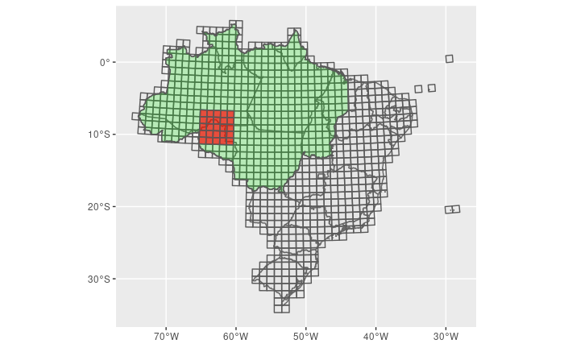

```r
federative_units <- sf::st_read("../data/shp/uf_2020/uf_2020.shp")
roi <- sf::st_read("../data/shp/roi_4326/roi.shp")
brazilian_amazon <- sf::st_read("../data/shp/brazilian_amazon/brazilian_legal_amazon.shp")
bdc_grid <- sf::st_read("../data/shp/bdc_sm/bdc_sm_4326.shp")
ggplot2::ggplot() +
  ggplot2::geom_sf(data = federative_units) +
  ggplot2::geom_sf(data = bdc_grid, alpha=1/10) +
  ggplot2::geom_sf(data = brazilian_amazon, fill = "green",alpha = 1/5) +
  ggplot2::geom_sf(data = roi, fill = "red",alpha = 1/1.5)
```

**Legend**

- Green - Legal Amazon Forest
- Red - Study area
- White - BDC grid
- Gray - Federative Units

# Data

The samples using a PRODES map to define their geographic location (longitude and latitude) and S2_SEN2COR_10_16D_STK-1 BDC cube provide the time series values. PRODES methodology allows us to define forest samples where it is possible to define a single class sample over two consecutive years safely. Considering deforestation areas, it is impossible to ensure a single class sample over these two years because the land cover can change along the selected period, e.g., pasture. However, it is possible to conclude that there was deforestation at the beginning of the time series period, and the ground truth is not a primary forest in all periods. The samples have 265026 time series: 182146 in forest and 82880 deforested areas. The R code above imports the samples and show the first six samples.

```r
samples <- readRDS("../data/samples/rds/2018-2021/samples.rds")
head(samples)
```

| longitude | latitude | start_date | end_date | label | cube | time_series | tile |
| --- | --- | --- | --- | --- | --- | --- | --- |
| -62.28473 | -9.306880 | 2018-07-28 | 2021-07-12 | Forest | S2-16D-2 |  | 014015 |
| -62.27983 | -9.300420 | 2018-07-28 | 2021-07-12 | Forest | S2-16D-2 |  | 014015 |
| -62.27827 | -9.086901 | 2018-07-28 | 2021-07-12 | Forest | S2-16D-2 |  | 014015 |
| -62.27656 | -9.027976 | 2018-07-28 | 2021-07-12 | Forest | S2-16D-2 |  | 014015 |
| -62.27561 | -9.002932 | 2018-07-28 | 2021-07-12 | Forest | S2-16D-2 |  | 014015 |
| -62.27545 | -8.991605 | 2018-07-28 | 2021-07-12 | Forest | S2-16D-2 |  | 014015 |

# Statistical Analysis

Statistical analysis is a mathematical procedure to investigate trends, patterns and relationship through quantitative data. The method consists in collect data and summarize it using a descriptive statistics. To draw a valid conclusions using statistical analysis is important develop carefully the sampling procedure, use inferential statistics to test hypotheses, make estimates about the population to finally interpret and generalize your findings.

# General Analysis

The statistic analysis can allow us to understand the temporal and spatial behavior of the samples, showing patterns, trends, relationships, and variability using quantitative data. We will start presenting a summary of the bands’ values by class. The data comprises sentinel observations, including twelve bands and two vegetation indexes. The code above summarizes the time series data along the time by class. In this summary, we can visualize basic statistical measurements for each band by class.

- Forest samples

```r
forest_samples <- samples[samples$label == "Forest",]
ts <- forest_samples$time_series
dt <- dt <- data.table::data.table(dplyr::bind_rows(ts))
summary(dt)
```

```
     Index                 B01               B02
 Min.   :2018-07-28   Min.   :0.00010   Min.   :0.00010
 1st Qu.:2019-04-23   1st Qu.:0.02203   1st Qu.:0.02340
 Median :2020-01-17   Median :0.03340   Median :0.03295
 Mean   :2020-01-18   Mean   :0.04685   Mean   :0.04408
 3rd Qu.:2020-10-15   3rd Qu.:0.05360   3rd Qu.:0.04925
 Max.   :2021-07-12   Max.   :1.00000   Max.   :0.99980
      B03               B04               B05
 Min.   :0.00010   Min.   :0.00010   Min.   :0.00010
 1st Qu.:0.03940   1st Qu.:0.02160   1st Qu.:0.06550
 Median :0.04977   Median :0.02920   Median :0.07800
 Mean   :0.05880   Mean   :0.03969   Mean   :0.08588
 3rd Qu.:0.06487   3rd Qu.:0.04260   3rd Qu.:0.09500
 Max.   :0.99960   Max.   :0.99910   Max.   :1.00000
      B06              B07              B08              B8A
 Min.   :0.0201   Min.   :0.0289   Min.   :0.0001   Min.   :0.0279
 1st Qu.:0.2033   1st Qu.:0.2611   1st Qu.:0.2593   1st Qu.:0.2925
 Median :0.2295   Median :0.2936   Median :0.2949   Median :0.3275
 Mean   :0.2329   Mean   :0.2965   Mean   :0.2951   Mean   :0.3294
 3rd Qu.:0.2614   3rd Qu.:0.3316   3rd Qu.:0.3327   3rd Qu.:0.3677
 Max.   :0.9989   Max.   :1.0000   Max.   :0.9996   Max.   :0.9977
      B09              B11              B12               NDVI
 Min.   :0.0001   Min.   :0.0024   Min.   :0.00150   Min.   :-0.3847
 1st Qu.:0.2931   1st Qu.:0.1404   1st Qu.:0.05780   1st Qu.: 0.7724
 Median :0.3241   Median :0.1591   Median :0.06780   Median : 0.8373
 Mean   :0.3347   Mean   :0.1636   Mean   :0.07729   Mean   : 0.7974
 3rd Qu.:0.3665   3rd Qu.:0.1837   3rd Qu.:0.08390   3rd Qu.: 0.8701
 Max.   :1.0000   Max.   :0.8366   Max.   :0.75820   Max.   : 0.9995
      EVI
 Min.   :-0.9952
 1st Qu.: 0.5288
 Median : 0.5827
 Mean   : 0.5816
 3rd Qu.: 0.6410
 Max.   : 1.0000
```

- Deforestation samples

```r
deforested_areas_samples <- samples[samples$label == "Deforested Areas",]
ts <- deforested_areas_samples$time_series
dt <- dt <- data.table::data.table(dplyr::bind_rows(ts))
summary(dt)
```

```
     Index                 B01               B02
 Min.   :2018-07-28   Min.   :0.00010   Min.   :0.00010
 1st Qu.:2019-04-23   1st Qu.:0.03330   1st Qu.:0.04030
 Median :2020-01-17   Median :0.04740   Median :0.05320
 Mean   :2020-01-18   Mean   :0.05981   Mean   :0.06275
 3rd Qu.:2020-10-15   3rd Qu.:0.07000   3rd Qu.:0.07320
 Max.   :2021-07-12   Max.   :0.99970   Max.   :0.99780
      B03               B04               B05              B06
 Min.   :0.00170   Min.   :0.00060   Min.   :0.0037   Min.   :0.0001
 1st Qu.:0.06520   1st Qu.:0.04845   1st Qu.:0.1042   1st Qu.:0.2067
 Median :0.07780   Median :0.06690   Median :0.1215   Median :0.2507
 Mean   :0.08563   Mean   :0.07476   Mean   :0.1274   Mean   :0.2514
 3rd Qu.:0.09665   3rd Qu.:0.09230   3rd Qu.:0.1444   3rd Qu.:0.2974
 Max.   :0.99600   Max.   :0.99820   Max.   :0.9980   Max.   :0.9982
      B07              B08              B8A              B09
 Min.   :0.0003   Min.   :0.0001   Min.   :0.0001   Min.   :0.0001
 1st Qu.:0.2421   1st Qu.:0.2411   1st Qu.:0.2710   1st Qu.:0.2746
 Median :0.2964   Median :0.2936   Median :0.3258   Median :0.3271
 Mean   :0.2980   Mean   :0.2930   Mean   :0.3258   Mean   :0.3318
 3rd Qu.:0.3549   3rd Qu.:0.3479   3rd Qu.:0.3839   3rd Qu.:0.3860
 Max.   :0.9917   Max.   :0.9994   Max.   :0.9985   Max.   :1.0000
      B11              B12              NDVI              EVI
 Min.   :0.0040   Min.   :0.0018   Min.   :-0.9661   Min.   :-0.9824
 1st Qu.:0.2070   1st Qu.:0.1071   1st Qu.: 0.5071   1st Qu.: 0.3620
 Median :0.2385   Median :0.1369   Median : 0.6480   Median : 0.4856
 Mean   :0.2429   Mean   :0.1471   Mean   : 0.6187   Mean   : 0.4771
 3rd Qu.:0.2767   3rd Qu.:0.1801   3rd Qu.: 0.7524   3rd Qu.: 0.5956
 Max.   :0.9994   Max.   :0.9945   Max.   : 0.9902   Max.   : 1.0000
```

To all values, we can observe a distortion between the median/mean and the maximum and maximum value measured for both the deforestation and the forest class. In this summary, the measures consider all values independent of the date, so we do not consider the temporal characteristic of the samples. These distortions can indicate that the observed value can not correspond to the actual land cover value at some point in the period. Some reasons for this can be the presence of clouds, aerosol interference, or pixel saturation. The interquartile range shows slight variation, indicating that most observed values have a singular pattern.

# Variation band

Above is presented a box plot for each band.

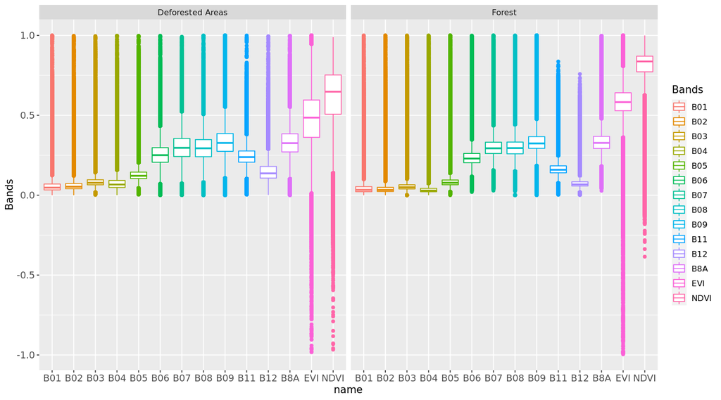

```r
plot_box(samples)
```

The interquartile variation is generally more significant for the Deforestation class than the Forest class, showing that the forest class presented a more homogeneous behavior. This behavior is expected considering the characteristics of the classes. The Amazon forest presents a massive tree concentration throughout the entire period. Meanwhile, deforestation is a non-homogeneous tree loss that can explain the variation, and the area can be another class, e.g., pasture. Still looking for the interquartile, the band variation is slight to all bands and slightly more significant to indexes. The bands B01 to B05 presented a slight variation considering the two classes. Contrasting Forest against Deforestation class, the band B12 to Forest class also presents a slight variation; meanwhile, the band B12 to Deforestation class presents more variation in comparison. The bands B06 to B11 present more variation in contrast to other bands. The indexes’ variation is more considerable, mainly considering the deforestation class. The median for the bands presents less variation to the classes compared to indexes; this shows how these indexes highlight the vegetation. All bands presented many numbers of outliers. To analyze these behaviors, we will explore the temporal characteristics to verify if these observations can be retired or if these outliers represent a natural variation considering clouds, for example.

Now, we are analyzing the behavior of the bands, considering the time variation. To simplify the visualization of the charts, we analyzed the two indexes (NDVI and EVI). Above, we plot two charts of the median and the quartiles. The command above calculated some statistics from the sample data: Mean, Median, Quartil 25%, Quartil 75%, Median, Standard deviation, and Correlation.

```r
stats <- stats_ts(samples)
```

- NDVI and EVI (Plotting Median and Quartils)

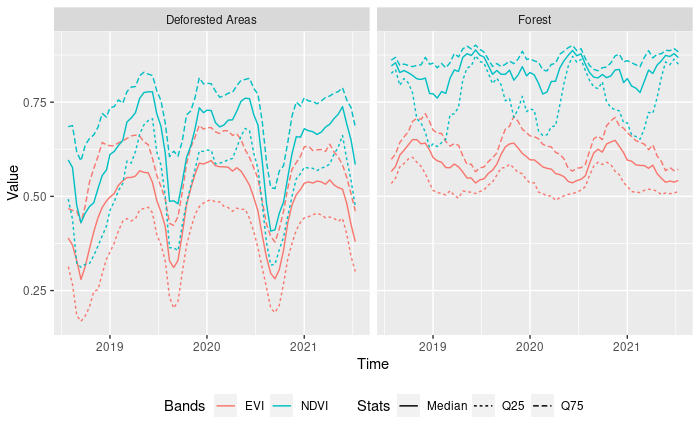

```r
plot_stats(stats, c("Median", "Q25", "Q75"), c("NDVI", "EVI"))
```

Analyzing the graphs, we can observe that the forest samples present a behavior with less variation in the median value over time than the deforestation class. The interquartile range for deforestation samples is generally considerably more extensive than for forest samples. In addition, the interquartile distance is more diminutive in periods of drought, indicating that the lower presence of clouds in this period drastically reduces the variability of observed values. The median of the indices for the deforestation samples presents two characteristic peaks in the rainy season and two valleys in the dry season. As for the forest samples, it is also possible to identify these peaks and valleys for the same periods. However, the values have a lower variance, highlighting the more homogeneous behavior for the vegetation indices over time. By contrasting the indices, we can see that in the case of deforestation samples, the general behavior of the median is similar for both indices, with lower values for EVI and higher values for NDVI. As for the forest samples, we can identify an almost opposite behavior for the indices. When the value increases for the EVI, the median value decreases for the NDVI.

# Pattern analysis

In time series analysis, it is helpful to visualize the temporal patterns to understand the band variability over the period. The chart above presents a statistical approximation of the samples in a single plot with all available sentinel bands and two vegetation indexes. The patterns represent an additive model (GAM) to obtain a possible predictor.

The following code presents the function sits_patterns(). It uses the dtwSat R package to generate the patterns used in the plot.

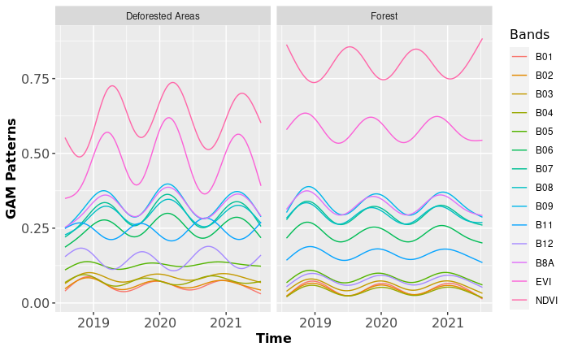

```r
patterns <- sits::sits_patterns(samples)
plot_patterns(patterns)
```

# Intra-class band Correlation

The previous patterns are sound indicative of the class’s behavior. Thus, their Correlation can support the previous analysis. The code below calculates the intra-class band correlation and plots it. Here, we desire to analyze numerically the relationship between the pattern bands of deforestation and Forest classes separately.

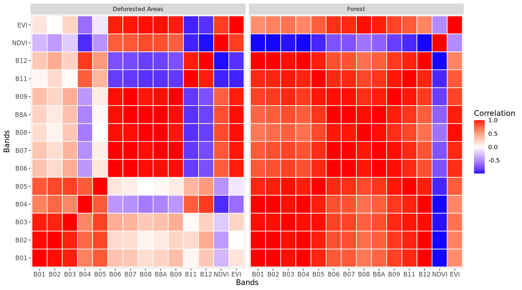

```r
intra_corr <- intra_class_correlation(patterns)
plot_intra_correlation(intra_corr)
```

The intra-class Correlation of the band’s patterns to forest patterns reveals a high positive correlation to all bands except the NDVI band, which presents a negative correlation to other bands. We can separate four groups with a high positive correlation in the deforestation class: 1 (B01 to B05), 2 (B06 to B09), 3 (B11 to B12), and 4 (NDVI and EVI). Analyze the groups against each other: Group 1 practically has no Correlation to other groups; Group 2 presents a negative correlation to 3 and a positive correlation to 4; Group 3 presents a negative Correlation to 4. The previous analysis covers group 4 correlation against other groups.

# Inter-class band Correlation

The code below calculates the inter-class band correlation and plots it. Here, we want to analyze the band patterns correlation class against class, comparing the respective band of deforestation patterns with forest patterns.

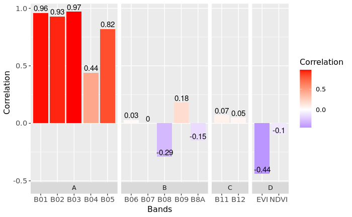

```r
inter_corr <- inter_class_correlation(patterns)
plot_inter_correlation(inter_corr)
```

# Bands Analysis

The previous intra-class Correlation analysis reveals that some band patterns are highly correlated. Indicating that some patterns have almost the same information, making it redundant to include them in an ML model. Including these highly correlated patterns in a model can lead to a multicollinearity problem. To avoid this problem, we developed a strategy to select features based on correlation analysis (Intra-class and Inter-class analysis). Based on the Intra-class correlation information to each class, we observed four groups with a high positive correlation considering the deforestation class. Through that information, we select the following bands by groups.

```r
bands <- c("B05", "B06", "B09","B12","NDVI", "EVI")
bcomb <- all_combinations(bands)
for(c in bcomb)print(c)
```

```
[1] "B05"
[1] "B06"
[1] "B09"
[1] "B12"
[1] "NDVI"
[1] "EVI"
[1] "B05" "B06"
[1] "B05" "B09"
[1] "B05" "B12"
[1] "B05"  "NDVI"
[1] "B05" "EVI"
[1] "B06" "B09"
[1] "B06" "B12"
[1] "B06"  "NDVI"
[1] "B06" "EVI"
```

[output cut: 48 more lines]

The evaluation of the clustering uses distinct cluster and classification metrics to define the quality of each model. To calculate the classification metrics, we define a label for each cluster based on the majority, where the cluster label will be the class with more members in the cluster. Below is presented the evaluated metrics:

**Clustering indexes**

- RI: Rand Index.
- ARI: Adjusted Rand Index.
- J: Jaccard Index.
- FM: Fowlkes-Mallows
- VI: Soft Variation of Information
- Sil: Silhouette index
- D: Dunn index
- COP: COP index

**Classification metrics**

- ACC: Accuracy.
- ACC_F: Accuracy to Forest samples (Not used in voting).
- ACC_D: Accuracy to Forest samples (Not used in voting)..
- PREC: Precision.
- SENS: Sensitivity.
- SPEC: Specificity.
- F1: F1-Score.

The training set consists of time series samples subdivided using the cube date range (2018-07-28 to 2019-07-12) closest to the PRODES 2018 mapping at tile 013015 (the center of region of interest). Bellow is presented the code to split the sample data considering these parameters:

```r
samples_013015 <- samples[samples$tile == "013015",]
training_samples <-subset_by_date (samples_013015, "2018-07-28","2019-07-12")
head(training_samples)
```

| latitude | longitude | start_date | end_date | label | cube | tile | time_series |
| --- | --- | --- | --- | --- | --- | --- | --- |
| -9.464475 | -63.26561 | 2018-07-28 | 2019-07-12 | Forest | S2-16D-2 | 013015 |  |
| -9.365091 | -63.26053 | 2018-07-28 | 2019-07-12 | Forest | S2-16D-2 | 013015 |  |
| -9.420402 | -63.26031 | 2018-07-28 | 2019-07-12 | Forest | S2-16D-2 | 013015 |  |
| -9.427100 | -63.26007 | 2018-07-28 | 2019-07-12 | Forest | S2-16D-2 | 013015 |  |
| -9.247444 | -63.25715 | 2018-07-28 | 2019-07-12 | Forest | S2-16D-2 | 013015 |  |
| -9.287999 | -63.25549 | 2018-07-28 | 2019-07-12 | Forest | S2-16D-2 | 013015 |  |

The models evaluation uses the k-fold cross validation using 20 percent of the data to test and 80 percent to train for each fold. The next code block generate the folds used.

```r
set.seed(123)
folds <- createFolds(training_samples$label, 5, FALSE)
write.csv(folds,file="../data/folds.csv",row.names=F)
```

- HC-DTW

```r
metrics_hcdtw <- empty_metric_df("unsupervised")
for(c in bcomb){
  training_samples_cbands <- sits_select(training_samples, c)
  metrics_k <- kfold_model("hcdtw", training_samples_cbands, folds)
  metrics_hcdtw <- rbind(metrics_hcdtw, metrics_k)
}
write.table(metrics_hcdtw , file = "../data/metrics_kfold_hcdtw.csv")
```

```r
best_model_voting(metrics)
```

|  | score_all | bands | RI | ARI | J | FM | Sil | D | CH | ACC | BACC | PREC | RECL | SENS | F1 | SPEC |
| --- | --- | --- | --- | --- | --- | --- | --- | --- | --- | --- | --- | --- | --- | --- | --- | --- |
| 16 | 5 | B09-B12 | 0.9913425 | 0.9820111 | 0.9855990 | 0.9927480 | 0.5197685 | 0.061794307 | 6161.275 | 0.9929153 | 0.9882542 | 0.9968635 | 0.9776997 | 0.9776997 | 0.9871851 | 0.9988086 |
| 61 | 4 | B05-B09-B12-NDVI-EVI | 0.9953944 | 0.9904271 | 0.9923180 | 0.9961442 | 0.5087914 | 0.058299818 | 7337.982 | 0.9755266 | 0.9566459 | 0.9983187 | 0.9138875 | 0.9138875 | 0.9541644 | 0.9994043 |
| 4 | 2 | B12 | 0.9917148 | 0.9827737 | 0.9862311 | 0.9930682 | 0.6892101 | 0.022557303 | 10053.557 | 0.9920567 | 0.9869525 | 0.9960742 | 0.9753942 | 0.9753942 | 0.9856032 | 0.9985108 |
| 6 | 1 | EVI | 0.8243538 | 0.6183309 | 0.7624994 | 0.8678686 | 0.5754259 | 0.034183986 | 7488.891 | 0.9223919 | 0.8612522 | 0.9989233 | 0.7228023 | 0.7228023 | 0.8384832 | 0.9997022 |
| 20 | 1 | B12-EVI | 0.9014593 | 0.7875182 | 0.8626129 | 0.9245339 | 0.5702901 | 0.052739222 | 6235.184 | 0.9635050 | 0.9348850 | 0.9991684 | 0.8700679 | 0.8700679 | 0.9295375 | 0.9997022 |
| 53 | 1 | B06-B09-B12-EVI | 0.9950208 | 0.9896499 | 0.9916993 | 0.9958319 | 0.4764159 | 0.073042319 | 5808.009 | 0.9794973 | 0.9638699 | 0.9979477 | 0.9284844 | 0.9284844 | 0.9618361 | 0.9992554 |
| 1 | 0 | B05 | 0.9684272 | 0.9344376 | 0.9484209 | 0.9735243 | 0.4781280 | 0.008730324 | 6067.548 | 0.9815378 | 0.9715324 | 0.9844242 | 0.9488727 | 0.9488727 | 0.9662981 | 0.9941921 |
| 2 | 0 | B06 | 0.7558593 | 0.4568057 | 0.6950047 | 0.8259007 | 0.3401530 | 0.024005051 | 3779.678 | 0.8680765 | 0.7715178 | 0.9563942 | 0.5528643 | 0.5528643 | 0.7005014 | 0.9901713 |
| 3 | 0 | B09 | 0.7673100 | 0.4826479 | 0.7073832 | 0.8335946 | 0.3942569 | 0.040203221 | 3018.732 | 0.8748404 | 0.7822242 | 0.9647397 | 0.5724900 | 0.5724900 | 0.7177926 | 0.9919583 |
| 5 | 0 | NDVI | 0.9787117 | 0.9556574 | 0.9651395 | 0.9822637 | 0.6058001 | 0.015674148 | 8254.488 | 0.9749892 | 0.9565056 | 0.9953955 | 0.9146493 | 0.9146493 | 0.9532631 | 0.9983619 |

[output cut: 53 more lines]

- RF

```r
metrics_rf <- empty_metric_df("supervised")
for(c in bcomb[52:63]){
  print(c)
  training_samples_cbands <- sits_select(training_samples, c)
  metrics_k <- kfold_model("rf", training_samples_cbands, folds)
  metrics_rf <- rbind(metrics_rf, metrics_k)
}
write.table(metrics_rf , file = "../data/csv/metrics_kfold_rf.csv")
```

|  | score_all | bands | ACC | BACC | PREC | RECL | SENS | F1 | SPEC |
| --- | --- | --- | --- | --- | --- | --- | --- | --- | --- |
| 52 | 3 | B06-B09-B12-NDVI | 0.9981751 | 0.9980271 | 0.9957825 | 0.9976923 | 0.9976923 | 0.9967339 | 0.9983619 |
| 54 | 2 | B06-B09-NDVI-EVI | 0.9978533 | 0.9979219 | 0.9942638 | 0.9980777 | 0.9980777 | 0.9961645 | 0.9977662 |
| 59 | 2 | B05-B06-B09-NDVI-EVI | 0.9976384 | 0.9969484 | 0.9961575 | 0.9953861 | 0.9953861 | 0.9957662 | 0.9985108 |
| 53 | 0 | B06-B09-B12-EVI | 0.9968872 | 0.9966629 | 0.9927289 | 0.9961553 | 0.9961553 | 0.9944347 | 0.9971705 |
| 55 | 0 | B06-B12-NDVI-EVI | 0.9980677 | 0.9979526 | 0.9954030 | 0.9976923 | 0.9976923 | 0.9965429 | 0.9982130 |
| 56 | 0 | B09-B12-NDVI-EVI | 0.9979604 | 0.9978782 | 0.9950249 | 0.9976923 | 0.9976923 | 0.9963522 | 0.9980640 |
| 57 | 0 | B05-B06-B09-B12-NDVI | 0.9979604 | 0.9977603 | 0.9954015 | 0.9973077 | 0.9973077 | 0.9963493 | 0.9982130 |
| 58 | 0 | B05-B06-B09-B12-EVI | 0.9969945 | 0.9967370 | 0.9931157 | 0.9961546 | 0.9961546 | 0.9946238 | 0.9973194 |
| 60 | 0 | B05-B06-B12-NDVI-EVI | 0.9978530 | 0.9975680 | 0.9954000 | 0.9969231 | 0.9969231 | 0.9961553 | 0.9982130 |
| 61 | 0 | B05-B09-B12-NDVI-EVI | 0.9977457 | 0.9973757 | 0.9953985 | 0.9965385 | 0.9965385 | 0.9959609 | 0.9982130 |

[output cut: 2 more lines]

# Generalization analysis

The generalization analysis uses distinct areas and periods, generating a robust test set. The spatial validation analysis uses samples at other tiles with the same period. The temporal validation generalization test uses a time series with distinct periods, more precisely, the next two years of original samples. At end, the spatio-temporal validation vary both time and geographic space.

- **BDC TILES**

```r
unique(samples$tile)
```

```
 [1] "014015" "014016" "012014" "012015" "012016" "013014" "013015" "013016" "014014"
[10] "011013" "011014" "015013" "015015" "011015" "011017" "012017" "013017" "014017"
[19] "012013" "013013" "014013" "015014" "015016" "011016" "015017"
```

- **Time Series time steps**

```r
samples$time_series[[1]]$Index
```

```
 [1] "2018-07-28" "2018-08-13" "2018-08-29" "2018-09-14" "2018-09-30" "2018-10-16"
 [7] "2018-11-01" "2018-11-17" "2018-12-03" "2018-12-19" "2019-01-01" "2019-01-17"
[13] "2019-02-02" "2019-02-18" "2019-03-06" "2019-03-22" "2019-04-07" "2019-04-23"
[19] "2019-05-09" "2019-05-25" "2019-06-10" "2019-06-26" "2019-07-12" "2019-07-28"
[25] "2019-08-13" "2019-08-29" "2019-09-14" "2019-09-30" "2019-10-16" "2019-11-01"
[31] "2019-11-17" "2019-12-03" "2019-12-19" "2020-01-01" "2020-01-17" "2020-02-02"
[37] "2020-02-18" "2020-03-05" "2020-03-21" "2020-04-06" "2020-04-22" "2020-05-08"
[43] "2020-05-24" "2020-06-09" "2020-06-25" "2020-07-11" "2020-07-27" "2020-08-12"
[49] "2020-08-28" "2020-09-13" "2020-09-29" "2020-10-15" "2020-10-31" "2020-11-16"
[55] "2020-12-02" "2020-12-18" "2021-01-01" "2021-01-17" "2021-02-02" "2021-02-18"
[61] "2021-03-06" "2021-03-22" "2021-04-07" "2021-04-23" "2021-05-09" "2021-05-25"
[67] "2021-06-10" "2021-06-26" "2021-07-12"
```

The test samples to each validation test has 23 time steps with the follow configuration:

- Validation
  - The same samples used to train models (`training_samples`)
  - Period: 2018-07-28 to 2019-07-12
  - Tiles: Only 013015
- Spatial Validation
  - Period: 2018-07-28 to 2019-07-12
  - Tiles: All tiles except 013015
  - Example:
- Temporal Validation
  - 1st Period: 2019-07-28 to 2020-07-11
  - 2nd Period: 2020-07-27 to 2021-07-12
  - Tile: Only 013015
  - Examples:
- Spatiotemporal Validation
  - 1st Period: 2019-07-28 to 2020-07-11
  - 2nd Period: 2020-07-27 to 2021-07-12
  - Tile: All tiles except 013015
  - Examples:

## Validation

In the validation, we build the models and evaluate the classification accuracy metrics to the samples used in the training stage. Bellow is recovered the samples in the tile 013015 at period 2018-07-28 to 2019-07-12 an it is show an example of the data set. In total we had 9316 time series: 6715 Forest and 2601 Deforested areas samples.

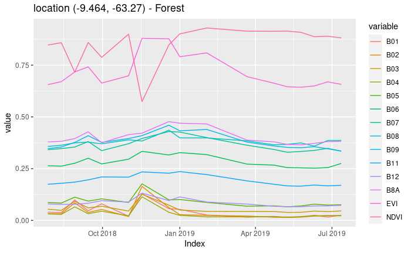

```r
samples_013015 <- samples[samples$tile == "013015",]
training_samples <-subset_by_date (samples_013015, "2018-07-28","2019-07-12")
ground_truth <- factor(
                  training_samples$label,
                  levels = sort(unique(training_samples$label)))
plot(training_samples[1,])
```

### Building the models and validation

#### HC-DTW

- Combination bands {B09,B12}

```r
ts_B09_B12 <- sits_select(training_samples, c("B09", "B12"))

hcdtw_B09_B12 <- hcdtw(ts_B09_B12)

predict_hcdtw_B09_B12 <- models_predict(hcdtw_B09_B12,
                                                   ts_B09_B12)
metrics <- classification_metrics(hcdtw_B09_B12,
                       predict_hcdtw_B09_B12,
                       ground_truth)

saveRDS(hcdtw_B09_B12, "../data/rds/model_hcdtw_B09_B12.rds")
write.table(metrics , file = "../data/csv/validations/metrics_hcdtw_B09_B12.csv")
```

```r
read.csv("../data/csv/validations/metrics_hcdtw_B09_B12.csv", sep=' ')
```

|  | bands | ACC | BACC | PREC | RECL | SENS | F1 | SPEC |
| --- | --- | --- | --- | --- | --- | --- | --- | --- |
| 1 | B09-B12 | 0.9943109 | 0.9908716 | 0.9964926 | 0.9830834 | 0.9830834 | 0.9897426 | 0.9986597 |

```r
ts_B05_B06_B09_NDVI_EVI <- sits_select(training_samples, c("B05",
                                              "B06",
                                              "B09",
                                              "NDVI",
                                              "EVI"))

hcdtw_B05_B06_B09_NDVI_EVI <- hcdtw(ts_B05_B06_B09_NDVI_EVI)

predict_hcdtw_B05_B06_B09_NDVI_EVI <- models_predict(hcdtw_B05_B06_B09_NDVI_EVI,
                                                   ts_B05_B06_B09_NDVI_EVI)

metrics <- classification_metrics(hcdtw_B05_B06_B09_NDVI_EVI,
                       predict_hcdtw_B05_B06_B09_NDVI_EVI,
                       ground_truth)

saveRDS(hcdtw_B05_B06_B09_NDVI_EVI,
        "../data/rds/model_hcdtw_B05_B06_B09_NDVI_EVI.rds")
write.table(metrics,
      file = "../data/csv/validations/metrics_hcdtw_B05_B06_B09_NDVI_EVI.csv")
```

```r
read.csv("../data/csv/validations/metrics_hcdtw_B05_B06_B09_NDVI_EVI.csv",
         sep=' ')
```

[output not shown]

#### RF

- Combination bands {B06,B09,B12,NDVI}

```r
ts_B06_B09_B12_NDVI <-sits_select(training_samples, c("B06","B09","B12","NDVI"))

rf_B06_B09_B12_NDVI <- rf()

rf_B06_B09_B12_NDVI <- sits_train(ts_B06_B09_B12_NDVI, rf_B06_B09_B12_NDVI)

predict_rf_B06_B09_B12_NDVI <- models_predict(rf_B06_B09_B12_NDVI,
                                                   ts_B06_B09_B12_NDVI)

metrics <- classification_metrics(rf_B06_B09_B12_NDVI,
                                  predict_rf_B06_B09_B12_NDVI,
                                  ground_truth)

saveRDS(rf_B06_B09_B12_NDVI, "../data/rds/model_rf_B06_B09_B12_NDVI.rds")
write.table(metrics ,
            file = "../data/csv/validations/metrics_rf_B06_B09_B12_NDVI.csv")
```

```r
read.csv("../data/csv/validations/metrics_rf_B06_B09_B12_NDVI.csv", sep=' ')
```

|  | bands | ACC | BACC | PREC | RECL | SENS | F1 | SPEC |
| --- | --- | --- | --- | --- | --- | --- | --- | --- |
| 1 | B06-B09-B12-NDVI | 1 | 1 | 1 | 1 | 1 | 1 | 1 |

- Combination bands {B05,B06,B09,NDVI,EVI}

```r
ts_B05_B06_B09_NDVI_EVI <- sits_select(training_samples, c("B05",
                                              "B06",
                                              "B09",
                                              "NDVI",
                                              "EVI"))

rf_B05_B06_B09_NDVI_EVI <- rf()

rf_B05_B06_B09_NDVI_EVI <- sits_train(ts_B05_B06_B09_NDVI_EVI,
                                      rf_B05_B06_B09_NDVI_EVI)

predict_rf_B05_B06_B09_NDVI_EVI <- models_predict(rf_B05_B06_B09_NDVI_EVI,
                                                   ts_B05_B06_B09_NDVI_EVI)

metrics <- classification_metrics(rf_B05_B06_B09_NDVI_EVI,
                       predict_rf_B05_B06_B09_NDVI_EVI,
                       ground_truth)

saveRDS(rf_B05_B06_B09_NDVI_EVI, "../data/rds/model_rf_B05_B06_B09_NDVI_EVI.rds")
write.table(metrics , file =
              "../data/csv/validations/metrics_rf_B05_B06_B09_NDVI_EVI.csv")
```

```r
read.csv("../data/csv/validations/metrics_rf_B05_B06_B09_NDVI_EVI.csv", sep=' ')
```

[output not shown]

## Spatial Validation

The spatial validation focus in evaluated the capacity of the models classify other areas different of the region of interest. The evaluation consists in calculate accuracy metrics varying the tiles. Note that, the models just trained using the tile 013015 as reference, so the test samples not uses images used in training. Bellow we recover time series at the same period (2018-07-28 to 2019-07-12) of the training samples but in other regions. Also is show an example of the time series sample used in the spatial validation.

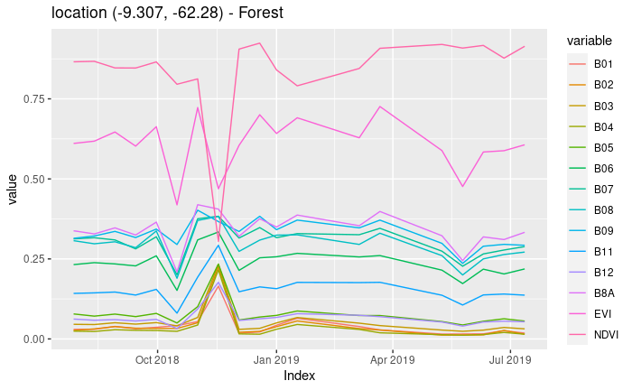

```r
spatial_samples <- samples[samples$tile != "013015",]
spatial_samples <-subset_by_date (spatial_samples,
                                       "2018-07-28",
                                       "2019-07-12")

plot(spatial_samples[1,])
```

Now we recover the models build before and apply the evaluated metrics.

```r
models_path <- "../data/rds"
predict_path <- "../data/csv/validations/spatial"

metrics <- run_metrics_path_models(models_path, spatial_samples, predict_path)
```

```
[1] "../data/rds/model_hcdtw_B05_B06_B09_NDVI_EVI.rds"
[1] "../data/csv/validations/spatial/model_hcdtw_B05_B06_B09_NDVI_EVI.csv"
[1] "../data/rds/model_hcdtw_B09_B12.rds"
[1] "../data/csv/validations/spatial/model_hcdtw_B09_B12.csv"
[1] "../data/rds/model_rf_B05_B06_B09_NDVI_EVI.rds"
[1] "../data/csv/validations/spatial/model_rf_B05_B06_B09_NDVI_EVI.csv"
[1] "../data/rds/model_rf_B06_B09_B12_NDVI.rds"
[1] "../data/csv/validations/spatial/model_rf_B06_B09_B12_NDVI.csv"
```

```r
write.table(metrics , file =
              "../data/csv/validations/metrics_spatial_validation.csv")
print(metrics)
```

| bands | ACC | BACC | PREC | RECL | SENS | F1 | SPEC | model_algorithm |
| --- | --- | --- | --- | --- | --- | --- | --- | --- |
| B05-B06-B09-NDVI-EVI | 0.9664425 | 0.9474267 | 0.9964273 | 0.8963241 | 0.8963241 | 0.9437286 | 0.9985293 | hcdtw |
| B09-B12 | 0.9886199 | 0.9829905 | 0.9957708 | 0.9678621 | 0.9678621 | 0.9816181 | 0.9981189 | hcdtw |
| B05-B06-B09-NDVI-EVI | 0.9951077 | 0.9940563 | 0.9931729 | 0.9912306 | 0.9912306 | 0.9922008 | 0.9968820 | rf |
| B06-B09-B12-NDVI | 0.9964530 | 0.9959522 | 0.9940986 | 0.9946063 | 0.9946063 | 0.9943524 | 0.9972981 | rf |

```r
NA
```

## Temporal Validation

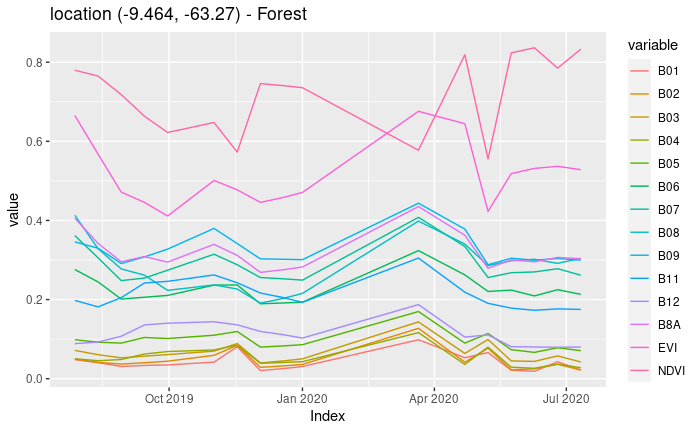

```r
  temporal_samples <- samples[samples$tile == "013015",]
  temporal_samples_1st <-subset_by_date (temporal_samples,
                                         "2019-07-28",
                                         "2020-07-11")
  plot(temporal_samples_1st[1,])
```

```r
models_path <- "../data/rds"
predict_path <- "../data/csv/validations/temporal/1st"

metrics <- run_metrics_path_models(models_path,
                                   temporal_samples_1st,
                                   predict_path)
```

```
[1] "../data/rds/model_hcdtw_B05_B06_B09_NDVI_EVI.rds"
[1] "../data/csv/validations/temporal/1st/model_hcdtw_B05_B06_B09_NDVI_EVI.csv"
[1] "../data/rds/model_hcdtw_B09_B12.rds"
[1] "../data/csv/validations/temporal/1st/model_hcdtw_B09_B12.csv"
[1] "../data/rds/model_rf_B05_B06_B09_NDVI_EVI.rds"
[1] "../data/csv/validations/temporal/1st/model_rf_B05_B06_B09_NDVI_EVI.csv"
[1] "../data/rds/model_rf_B06_B09_B12_NDVI.rds"
[1] "../data/csv/validations/temporal/1st/model_rf_B06_B09_B12_NDVI.csv"
```

```r
write.table(metrics , file =
              "../data/csv/validations/metrics_temporal_1stvalidation.csv")
print(metrics)
```

| bands | ACC | BACC | PREC | RECL | SENS | F1 | SPEC | model_algorithm |
| --- | --- | --- | --- | --- | --- | --- | --- | --- |
| B05-B06-B09-NDVI-EVI | 0.9690854 | 0.9456966 | 0.9961390 | 0.8927336 | 0.8927336 | 0.9416058 | 0.9986597 | hcdtw |
| B09-B12 | 0.9930228 | 0.9891536 | 0.9945398 | 0.9803922 | 0.9803922 | 0.9874153 | 0.9979151 | hcdtw |
| B05-B06-B09-NDVI-EVI | 0.9960283 | 0.9954784 | 0.9915644 | 0.9942330 | 0.9942330 | 0.9928969 | 0.9967238 | rf |
| B06-B09-B12-NDVI | 0.9961357 | 0.9960239 | 0.9904398 | 0.9957709 | 0.9957709 | 0.9930982 | 0.9962770 | rf |

```r
NA
```

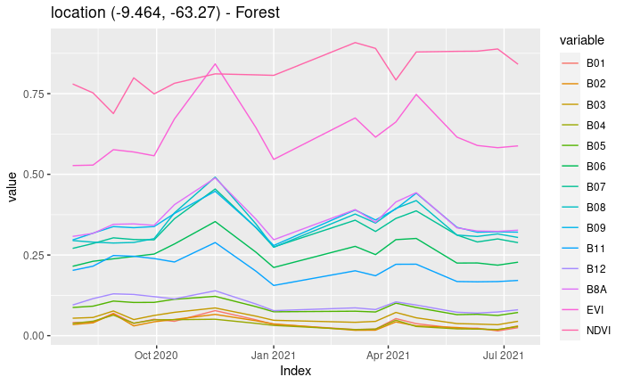

```r
  temporal_samples_2nd <-subset_by_date (temporal_samples,
                                         "2020-07-27",
                                         "2021-07-12")
  plot(temporal_samples_2nd[1,])
```

```r
models_path <- "../data/rds"
predict_path <- "../data/csv/validations/temporal/2nd"

metrics <- run_metrics_path_models(models_path,
                                   temporal_samples_2nd,
                                   predict_path)
```

```
[1] "../data/rds/model_hcdtw_B05_B06_B09_NDVI_EVI.rds"
[1] "../data/csv/validations/temporal/2nd/model_hcdtw_B05_B06_B09_NDVI_EVI.csv"
[1] "../data/rds/model_hcdtw_B09_B12.rds"
[1] "../data/csv/validations/temporal/2nd/model_hcdtw_B09_B12.csv"
[1] "../data/rds/model_rf_B05_B06_B09_NDVI_EVI.rds"
[1] "../data/csv/validations/temporal/2nd/model_rf_B05_B06_B09_NDVI_EVI.csv"
[1] "../data/rds/model_rf_B06_B09_B12_NDVI.rds"
[1] "../data/csv/validations/temporal/2nd/model_rf_B06_B09_B12_NDVI.csv"
```

```r
write.table(metrics , file =
              "../data/csv/validations/metrics_temporal_2ndvalidation.csv")
print(metrics)
```

| bands | ACC | BACC | PREC | RECL | SENS | F1 | SPEC | model_algorithm |
| --- | --- | --- | --- | --- | --- | --- | --- | --- |
| B05-B06-B09-NDVI-EVI | 0.9920567 | 0.9864813 | 0.9976369 | 0.9738562 | 0.9738562 | 0.9856031 | 0.9991065 | hcdtw |
| B09-B12 | 0.9949549 | 0.9924961 | 0.9949612 | 0.9869281 | 0.9869281 | 0.9909284 | 0.9980640 | hcdtw |
| B05-B06-B09-NDVI-EVI | 0.9965650 | 0.9969106 | 0.9900801 | 0.9976932 | 0.9976932 | 0.9938721 | 0.9961281 | rf |
| B06-B09-B12-NDVI | 0.9949549 | 0.9957937 | 0.9844461 | 0.9976932 | 0.9976932 | 0.9910254 | 0.9938943 | rf |

```r
NA
```

## Spatiotemporal Validation

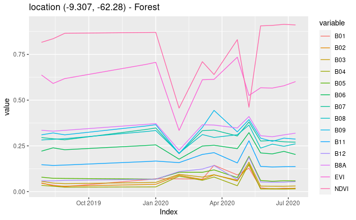

```r
  spatiotemporal_samples <- samples[samples$tile != "013015",]
  spatiotemporal_samples_1st <-subset_by_date (spatiotemporal_samples,
                                         "2019-07-28",
                                         "2020-07-11")

  plot(spatiotemporal_samples_1st[1,])
```

```r
models_path <- "../data/rds"
predict_path <- "../data/csv/validations/spatiotemporal/1st"
metrics <- run_metrics_path_models(models_path,
                                   spatiotemporal_samples_1st,
                                   predict_path)
```

```
[1] "../data/rds/model_hcdtw_B05_B06_B09_NDVI_EVI.rds"
[1] "../data/csv/validations/spatiotemporal/1st/model_hcdtw_B05_B06_B09_NDVI_EVI.csv"
[1] "../data/rds/model_hcdtw_B09_B12.rds"
[1] "../data/csv/validations/spatiotemporal/1st/model_hcdtw_B09_B12.csv"
[1] "../data/rds/model_rf_B05_B06_B09_NDVI_EVI.rds"
[1] "../data/csv/validations/spatiotemporal/1st/model_rf_B05_B06_B09_NDVI_EVI.csv"
[1] "../data/rds/model_rf_B06_B09_B12_NDVI.rds"
[1] "../data/csv/validations/spatiotemporal/1st/model_rf_B06_B09_B12_NDVI.csv"
```

```r
write.table(metrics , file =
            "../data/csv/validations/metrics_spatiotemporal_1stvalidation.csv")
print(metrics)
```

| bands | ACC | BACC | PREC | RECL | SENS | F1 | SPEC | model_algorithm |
| --- | --- | --- | --- | --- | --- | --- | --- | --- |
| B05-B06-B09-NDVI-EVI | 0.9540691 | 0.9281055 | 0.9946303 | 0.8583316 | 0.8583316 | 0.9214681 | 0.9978795 | hcdtw |
| B09-B12 | 0.9837355 | 0.9754749 | 0.9946969 | 0.9532755 | 0.9532755 | 0.9735458 | 0.9976743 | hcdtw |
| B05-B06-B09-NDVI-EVI | 0.9950960 | 0.9951118 | 0.9892886 | 0.9951544 | 0.9951544 | 0.9922128 | 0.9950693 | rf |
| B06-B09-B12-NDVI | 0.9960737 | 0.9961825 | 0.9910676 | 0.9964748 | 0.9964748 | 0.9937638 | 0.9958901 | rf |

```r
NA
```

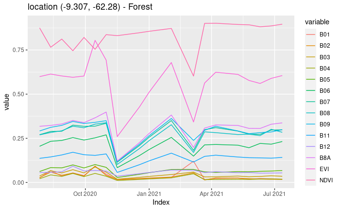

```r
  spatiotemporal_samples_2nd <-subset_by_date (spatiotemporal_samples,
                                         "2020-07-27",
                                         "2021-07-12")
  plot(spatiotemporal_samples_2nd[1,])
```

```r
models_path <- "../data/rds"
predict_path <- "../data/csv/validations/spatiotemporal/2nd"

metrics <- run_metrics_path_models(models_path,
                                   spatiotemporal_samples_2nd,
                                   predict_path)
```

```
[1] "../data/rds/model_hcdtw_B05_B06_B09_NDVI_EVI.rds"
[1] "../data/csv/validations/spatiotemporal/2nd/model_hcdtw_B05_B06_B09_NDVI_EVI.csv"
[1] "../data/rds/model_hcdtw_B09_B12.rds"
[1] "../data/csv/validations/spatiotemporal/2nd/model_hcdtw_B09_B12.csv"
[1] "../data/rds/model_rf_B05_B06_B09_NDVI_EVI.rds"
[1] "../data/csv/validations/spatiotemporal/2nd/model_rf_B05_B06_B09_NDVI_EVI.csv"
[1] "../data/rds/model_rf_B06_B09_B12_NDVI.rds"
[1] "../data/csv/validations/spatiotemporal/2nd/model_rf_B06_B09_B12_NDVI.csv"
```

```r
write.table(metrics , file =
            "../data/csv/validations/metrics_spatiotemporal_2ndvalidation.csv")
print(metrics)
```

| bands | ACC | BACC | PREC | RECL | SENS | F1 | SPEC | model_algorithm |
| --- | --- | --- | --- | --- | --- | --- | --- | --- |
| B05-B06-B09-NDVI-EVI | 0.9882719 | 0.9825071 | 0.9954990 | 0.9670150 | 0.9670150 | 0.9810503 | 0.9979992 | hcdtw |
| B09-B12 | 0.9935708 | 0.9910444 | 0.9952138 | 0.9842549 | 0.9842549 | 0.9897040 | 0.9978339 | hcdtw |
| B05-B06-B09-NDVI-EVI | 0.9957061 | 0.9961476 | 0.9890795 | 0.9973343 | 0.9973343 | 0.9931898 | 0.9949610 | rf |
| B06-B09-B12-NDVI | 0.9959133 | 0.9965656 | 0.9887729 | 0.9983184 | 0.9983184 | 0.9935227 | 0.9948128 | rf |

```r
NA
```